# Multi-level pca analysis

M.Davids

19 mei, 2021

# Introduction

Multi-level PCA (mPCA) can be used to visualize longitudinal data were we want to remove the inter-individual variance, which can obscure possible treatment effects. The following code shows an example on a toy dataset. Once we understand how the data is tranformed, we can more easily understand the multi-level pca.

# Install and load required packages

```r
#renv::init()

cran <- c("ggplot2",
          "ggpubr",
          "ape",
          "ggfortify",
          NULL)

install.packages(cran[!cran %in% installed.packages()])

bioc. <- c("phyloseq",
           "mixOmics",
           NULL)
#BiocManager::install(bioc.[!bioc. %in% installed.packages()])

library(phyloseq)
library(mixOmics)
library(ggplot2)
library(ggpubr)
library(ggfortify)
```

# Toy data

Lets create a toy data set with 8 subjects and 16 features and two time points.

First we generate the baseline data. There is no confounding factor and all measurements are independent from the same distribution.

```r
nsample=8
nfeatures=16

set.seed(1);toy_data <- matrix(data = sample(x = 1:10, size = nsample*nfeatures, replace = T), nrow = nsample, ncol = nfeatures, dimnames = list(paste0("s",1:nsample,"_t1"),paste0("f",1:nfeatures)))

toy_data
```

```
##       f1 f2 f3 f4 f5 f6 f7 f8 f9 f10 f11 f12 f13 f14 f15 f16
## s1_t1  9  1  5  9  4  9  6  3  4   1   6   1   5   6   3   6
## s2_t1  4  5  5  1  4  7  8  8  8   5   2  10   6   6   7   1
## s3_t1  7  5  9  4 10  8  2  6  9   6  10  10   8   4   3   2
## s4_t1  1 10  9  3  9  6  2  7  9   1  10   8   1   9   3   7
## s5_t1  2  6  5  6  7 10  6  6  7   9   7  10   3   5   1   7
## s6_t1  7 10  5 10  6  7  6  8  4   7   3   5  10   1   9   4
## s7_t1  2  7  2 10  9  3  1  7  7   7   2   7   3   3   2   9
## s8_t1  3  9 10  6  8 10  3  1  6   3  10   8   1   6   8   8
```

Now lets generate the second time point data, which is completely independent of the baseline.

```r
set.seed(2);toy_data2 <- matrix(data = sample(x = 1:10, size = nsample*nfeatures, replace = T), nrow = nsample, ncol = nfeatures, dimnames = list(paste0("s",1:nsample,"_t2"),paste0("f",1:nfeatures)))

toy_data_merged <- rbind(toy_data, toy_data2)
toy_data_merged
```

```
##       f1 f2 f3 f4 f5 f6 f7 f8 f9 f10 f11 f12 f13 f14 f15 f16
## s1_t1  9  1  5  9  4  9  6  3  4   1   6   1   5   6   3   6
## s2_t1  4  5  5  1  4  7  8  8  8   5   2  10   6   6   7   1
## s3_t1  7  5  9  4 10  8  2  6  9   6  10  10   8   4   3   2
## s4_t1  1 10  9  3  9  6  2  7  9   1  10   8   1   9   3   7
## s5_t1  2  6  5  6  7 10  6  6  7   9   7  10   3   5   1   7
## s6_t1  7 10  5 10  6  7  6  8  4   7   3   5  10   1   9   4
## s7_t1  2  7  2 10  9  3  1  7  7   7   2   7   3   3   2   9
## s8_t1  3  9 10  6  8 10  3  1  6   3  10   8   1   6   8   8
## s1_t2  5  1  1  3  3  8  6  3 10   9   4   7   3   1   5   7
## s2_t2  6  3  6  9  4  4  4  3  9  10   1   3   1   2   8   8
## s3_t2  6  6  9  7  3  5  4  8  5   5   4   5   7  10   4   3
## s4_t2  8  2  4  8  1  2  9  6  8   1   6   4   9   4   2   8
## s5_t2  1  3  6  6  7  5 10  1  4   9   8   5   5   9   8  10
## s6_t2  1  7  9  2  9  6  2  5  1   2   9   9   3   1   1   1
## s7_t2  9  8  8  7  1  7  6  6  1   9   6   5   3   7   5   1
## s8_t2  2  7  6  2  2  2  6  1  5   7   7  10   6   3   4   4
```

Lets add a design

```r
toy_data_design <- data.frame(row.names = rownames(toy_data_merged),
                              treatment=factor(rep(c(rep(1,4),rep(2,4)),2)),
                              time_point=factor(c(rep(1,8),rep(2,8))),
                              subject=gsub("_.*","",rownames(toy_data_merged)))
toy_data_design
```

```
##       treatment time_point subject
## s1_t1         1          1      s1
## s2_t1         1          1      s2
## s3_t1         1          1      s3
## s4_t1         1          1      s4
## s5_t1         2          1      s5
## s6_t1         2          1      s6
## s7_t1         2          1      s7
## s8_t1         2          1      s8
## s1_t2         1          2      s1
## s2_t2         1          2      s2
## s3_t2         1          2      s3
## s4_t2         1          2      s4
## s5_t2         2          2      s5
## s6_t2         2          2      s6
## s7_t2         2          2      s7
## s8_t2         2          2      s8
```

We can visualize using simple pca.

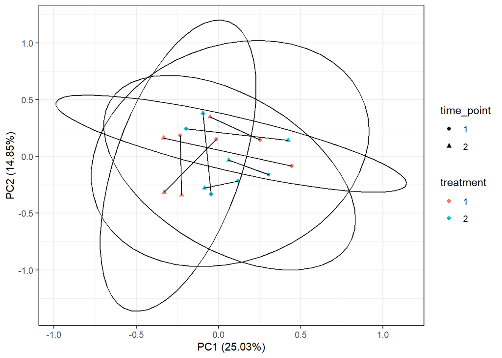

```r
pca_out <- prcomp(toy_data_merged)
autoplot(pca_out, data = toy_data_design, colour="treatment", shape="time_point") +
  theme_bw() +
  geom_line(aes(group=subject)) +
  stat_ellipse(aes(group=interaction(treatment, time_point)))
```

As you can see all data is scattered and no obvious patterns, as it should Now use mPCA to visualize the results.

```r
mpca <- pca(X = toy_data_merged, multilevel = toy_data_design$subject, ncomp = 10)
```

```
## Splitting the variation for 1 level factor.
```

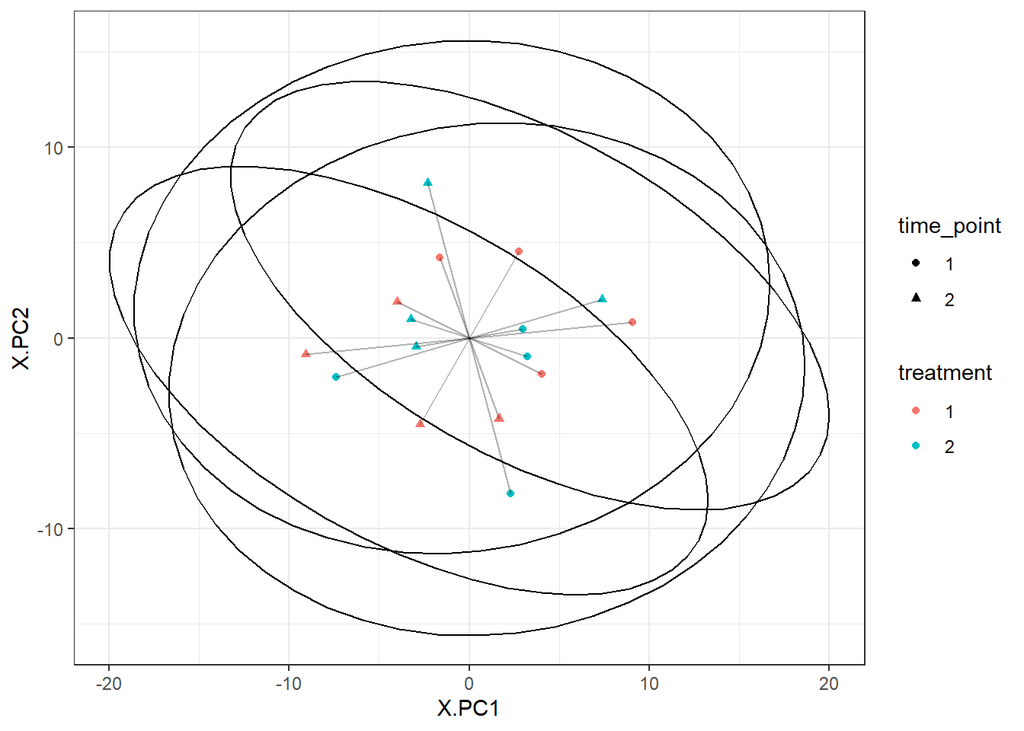

```r
df <- cbind(mpca$variates, toy_data_design)

ggplot(df, aes(x=X.PC1, y=X.PC2)) +
  theme_bw() +
  geom_point(aes(color=treatment, shape=time_point)) +
  geom_line(aes(group=subject), alpha=0.3) +
  stat_ellipse(aes(group=interaction(treatment, time_point)))
```

Also in this plot we dont see any patterns.

# Subject variance

Now lets make the second timepoint dependent on the first measurement and add some random noise by either substracting or adding one count, or not changing at all.

```r
set.seed(2);toy_data2 <- toy_data-sample(c(-1,0,1), size = nsample*nfeatures, replace = T)

toy_data_merged <- rbind(toy_data, toy_data2)
toy_data_merged
```

```
##       f1 f2 f3 f4 f5 f6 f7 f8 f9 f10 f11 f12 f13 f14 f15 f16
## s1_t1  9  1  5  9  4  9  6  3  4   1   6   1   5   6   3   6
## s2_t1  4  5  5  1  4  7  8  8  8   5   2  10   6   6   7   1
## s3_t1  7  5  9  4 10  8  2  6  9   6  10  10   8   4   3   2
## s4_t1  1 10  9  3  9  6  2  7  9   1  10   8   1   9   3   7
## s5_t1  2  6  5  6  7 10  6  6  7   9   7  10   3   5   1   7
## s6_t1  7 10  5 10  6  7  6  8  4   7   3   5  10   1   9   4
## s7_t1  2  7  2 10  9  3  1  7  7   7   2   7   3   3   2   9
## s8_t1  3  9 10  6  8 10  3  1  6   3  10   8   1   6   8   8
## s1_t1 10  2  4 10  5  8  7  3  4   2   7   1   4   5   3   5
## s2_t1  3  5  4  1  5  8  8  8  7   6   2  10   7   5   6   2
## s3_t1  7  4  8  5 10  7  3  5  8   6  11  11   8   5   2   1
## s4_t1  1 11 10  3  9  7  2  8 10   2   9   7   2  10   4   7
## s5_t1  3  5  5  6  7 11  7  6  6   9   8  11   4   4   0   6
## s6_t1  8 10  6  9  5  6  6  7  4   8   2   6  10   2   8   4
## s7_t1  3  7  1 11  9  4  2  7  8   8   3   7   2   4   2  10
## s8_t1  4  8 10  5  7 10  2  1  7   2   9   9   1   7   9   8
```

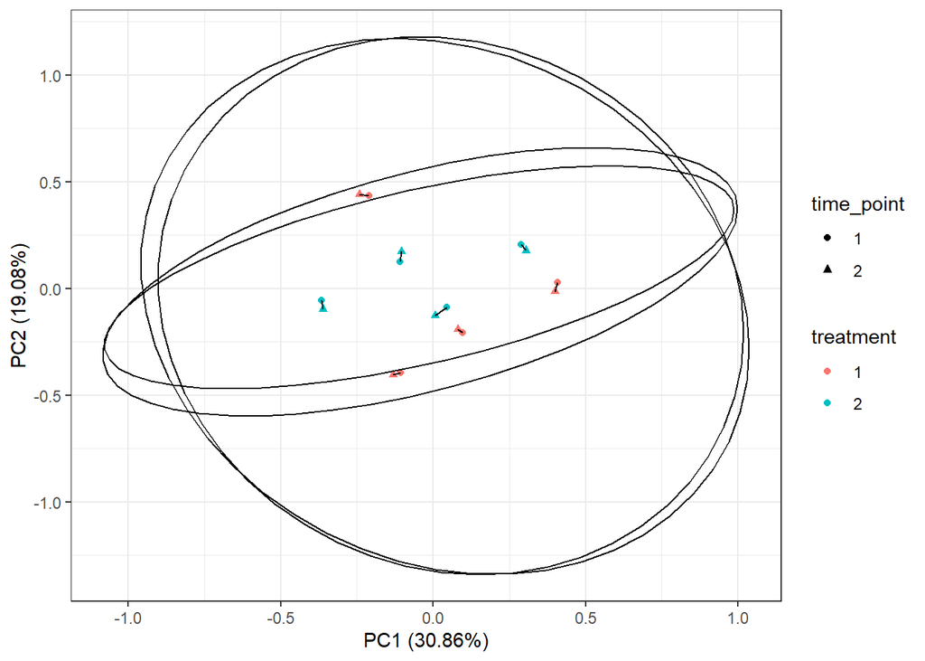

```r
pca_out <- prcomp(toy_data_merged)
autoplot(pca_out, data = toy_data_design, colour="treatment", shape="time_point") +
  theme_bw() +
  geom_line(aes(group=subject)) +
  stat_ellipse(aes(group=interaction(treatment, time_point)))
```

Now we can see a clearly see all the inter-individual variance. We can correct for all subject specific variance using mPCA.

```r
mpca <- pca(X = toy_data_merged, multilevel = toy_data_design$subject, ncomp = 10)
```

```
## Splitting the variation for 1 level factor.
```

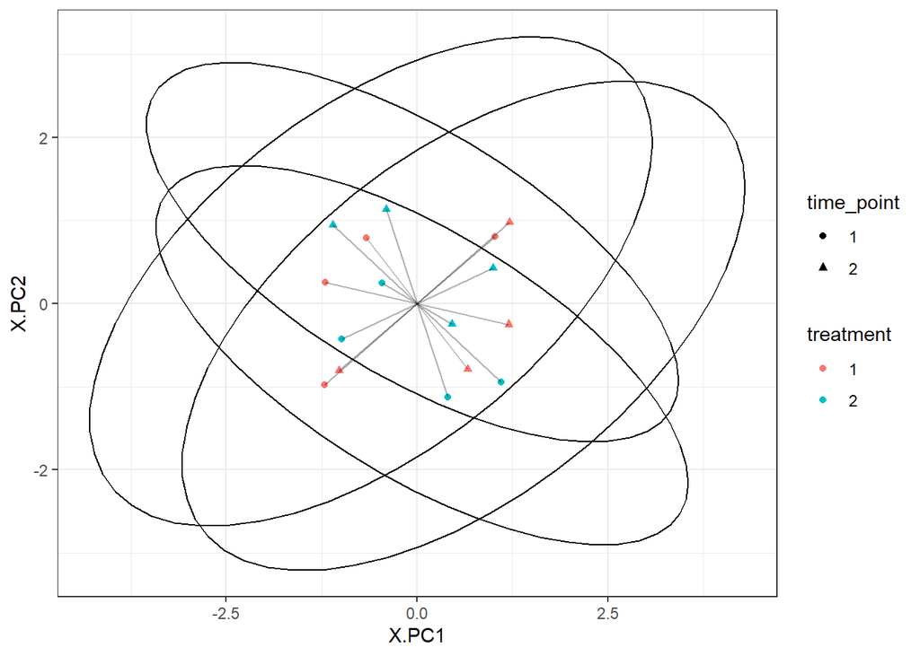

```r
df <- cbind(mpca$variates, toy_data_design)

ggplot(df, aes(x=X.PC1, y=X.PC2)) +
  theme_bw() +
  geom_point(aes(color=treatment, shape=time_point)) +
  geom_line(aes(group=subject), alpha=0.3) +
  stat_ellipse(aes(group=interaction(treatment, time_point)))
```

Now all interindivual subject variance has been removed from the ordination. And no treatment or time effect can be observed.

Lets have a look at the transformed data that the mixOmics package generated.

```r
mpca$X
```

```
##         f1   f2   f3   f4   f5   f6   f7   f8   f9  f10  f11  f12  f13  f14
## s1_t1 -0.5 -0.5  0.5 -0.5 -0.5  0.5 -0.5  0.0  0.0 -0.5 -0.5  0.0  0.5  0.5
## s2_t1  0.5  0.0  0.5  0.0 -0.5 -0.5  0.0  0.0  0.5 -0.5  0.0  0.0 -0.5  0.5
## s3_t1  0.0  0.5  0.5 -0.5  0.0  0.5 -0.5  0.5  0.5  0.0 -0.5 -0.5  0.0 -0.5
## s4_t1  0.0 -0.5 -0.5  0.0  0.0 -0.5  0.0 -0.5 -0.5 -0.5  0.5  0.5 -0.5 -0.5
## s5_t1 -0.5  0.5  0.0  0.0  0.0 -0.5 -0.5  0.0  0.5  0.0 -0.5 -0.5 -0.5  0.5
## s6_t1 -0.5  0.0 -0.5  0.5  0.5  0.5  0.0  0.5  0.0 -0.5  0.5 -0.5  0.0 -0.5
## s7_t1 -0.5  0.0  0.5 -0.5  0.0 -0.5 -0.5  0.0 -0.5 -0.5 -0.5  0.0  0.5 -0.5
## s8_t1 -0.5  0.5  0.0  0.5  0.5  0.0  0.5  0.0 -0.5  0.5  0.5 -0.5  0.0 -0.5
## s1_t1  0.5  0.5 -0.5  0.5  0.5 -0.5  0.5  0.0  0.0  0.5  0.5  0.0 -0.5 -0.5
## s2_t1 -0.5  0.0 -0.5  0.0  0.5  0.5  0.0  0.0 -0.5  0.5  0.0  0.0  0.5 -0.5
## s3_t1  0.0 -0.5 -0.5  0.5  0.0 -0.5  0.5 -0.5 -0.5  0.0  0.5  0.5  0.0  0.5
## s4_t1  0.0  0.5  0.5  0.0  0.0  0.5  0.0  0.5  0.5  0.5 -0.5 -0.5  0.5  0.5
## s5_t1  0.5 -0.5  0.0  0.0  0.0  0.5  0.5  0.0 -0.5  0.0  0.5  0.5  0.5 -0.5
## s6_t1  0.5  0.0  0.5 -0.5 -0.5 -0.5  0.0 -0.5  0.0  0.5 -0.5  0.5  0.0  0.5
## s7_t1  0.5  0.0 -0.5  0.5  0.0  0.5  0.5  0.0  0.5  0.5  0.5  0.0 -0.5  0.5
## s8_t1  0.5 -0.5  0.0 -0.5 -0.5  0.0 -0.5  0.0  0.5 -0.5 -0.5  0.5  0.0  0.5
##        f15  f16
## s1_t1  0.0  0.5
## s2_t1  0.5 -0.5
## s3_t1  0.5  0.5
## s4_t1 -0.5  0.0
## s5_t1  0.5  0.5
## s6_t1  0.5  0.0
## s7_t1  0.0 -0.5
## s8_t1 -0.5  0.0
## s1_t1  0.0 -0.5
## s2_t1 -0.5  0.5
## s3_t1 -0.5 -0.5
## s4_t1  0.5  0.0
## s5_t1 -0.5 -0.5
## s6_t1 -0.5  0.0
## s7_t1  0.0  0.5
## s8_t1  0.5  0.0
## attr(,"scaled:center")
##  f1  f2  f3  f4  f5  f6  f7  f8  f9 f10 f11 f12 f13 f14 f15 f16
##   0   0   0   0   0   0   0   0   0   0   0   0   0   0   0   0
```

We either added or substracted 1 from the count table. As we can see this difference is averaged over the two time points. So effectively we are doing a pca on the deltas. This is the reason the plot is symmetrical.

# Time effect

Now lets add some time effect by either adding or substracting.

```r
set.seed(3);toy_data3 <- toy_data2+matrix(rep(sample(c(-1,0,0,0,1), size = nfeatures, replace = T), nsample), ncol = nfeatures, byrow = T)

toy_data_merged <- rbind(toy_data, toy_data3)
toy_data_merged
```

```
##       f1 f2 f3 f4 f5 f6 f7 f8 f9 f10 f11 f12 f13 f14 f15 f16
## s1_t1  9  1  5  9  4  9  6  3  4   1   6   1   5   6   3   6
## s2_t1  4  5  5  1  4  7  8  8  8   5   2  10   6   6   7   1
## s3_t1  7  5  9  4 10  8  2  6  9   6  10  10   8   4   3   2
## s4_t1  1 10  9  3  9  6  2  7  9   1  10   8   1   9   3   7
## s5_t1  2  6  5  6  7 10  6  6  7   9   7  10   3   5   1   7
## s6_t1  7 10  5 10  6  7  6  8  4   7   3   5  10   1   9   4
## s7_t1  2  7  2 10  9  3  1  7  7   7   2   7   3   3   2   9
## s8_t1  3  9 10  6  8 10  3  1  6   3  10   8   1   6   8   8
## s1_t1 11  2  4 10  5  8  7  3  5   2   8   1   5   6   4   4
## s2_t1  4  5  4  1  5  8  8  8  8   6   3  10   8   6   7   1
## s3_t1  8  4  8  5 10  7  3  5  9   6  12  11   9   6   3   0
## s4_t1  2 11 10  3  9  7  2  8 11   2  10   7   3  11   5   6
## s5_t1  4  5  5  6  7 11  7  6  7   9   9  11   5   5   1   5
## s6_t1  9 10  6  9  5  6  6  7  5   8   3   6  11   3   9   3
## s7_t1  4  7  1 11  9  4  2  7  9   8   4   7   3   5   3   9
## s8_t1  5  8 10  5  7 10  2  1  8   2  10   9   2   8  10   7
```

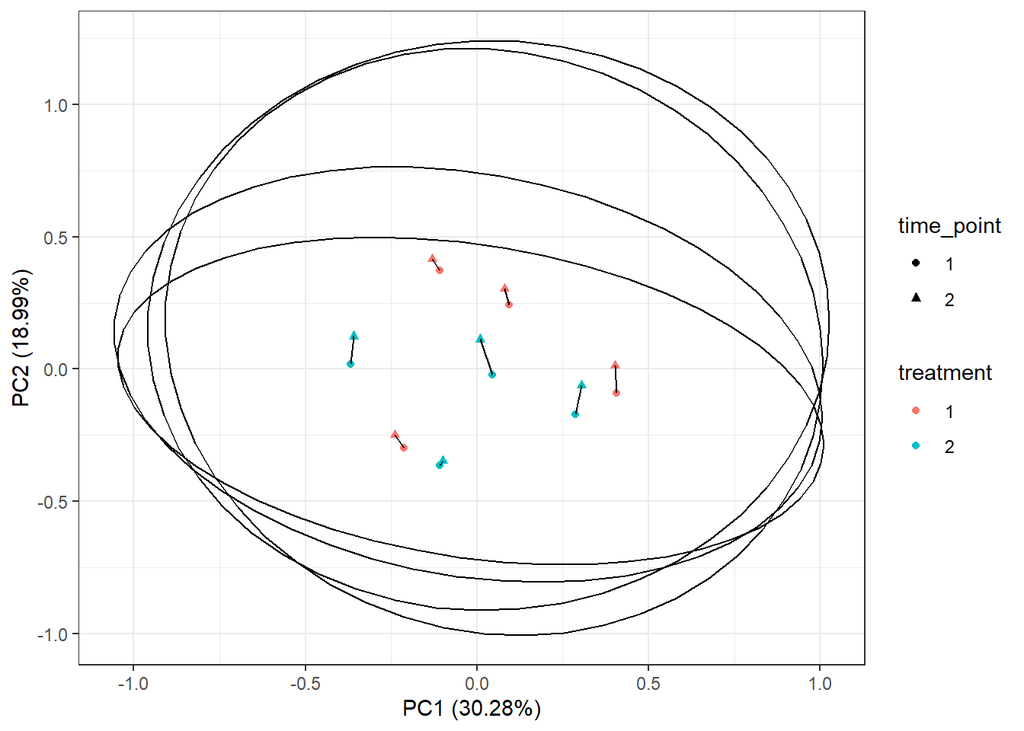

```r
pca_out <- prcomp(toy_data_merged)
autoplot(pca_out, data = toy_data_design, colour="treatment", shape="time_point") +
  theme_bw() +
  geom_line(aes(group=subject)) +
  stat_ellipse(aes(group=interaction(treatment, time_point)))
```

The interindividual differences are this the major source of variance and a small time effect can be observed (PC2).

```r
mpca <- pca(X = toy_data_merged, multilevel = toy_data_design$subject, ncomp = 10)
```

```
## Splitting the variation for 1 level factor.
```

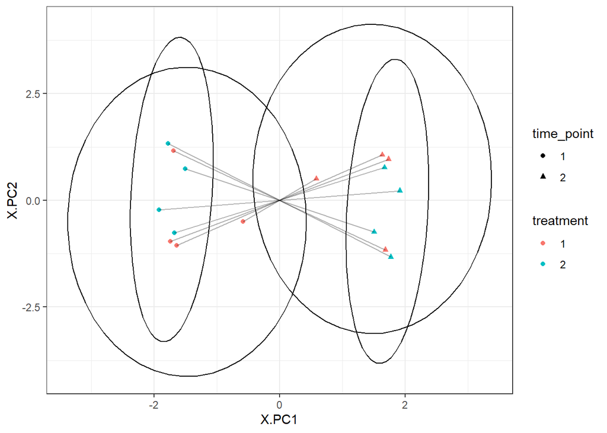

```r
df <- cbind(mpca$variates, toy_data_design)

ggplot(df, aes(x=X.PC1, y=X.PC2)) +
  theme_bw() +
  geom_point(aes(color=treatment, shape=time_point)) +
  geom_line(aes(group=subject), alpha=0.3) +
  stat_ellipse(aes(group=interaction(treatment, time_point)))
```

With the multilevel pca, time effect is very obvious.

# Treatment

Now lets add treatment effect.

```r
set.seed(3);effect <- matrix(rep(sample(c(-1,0,1), size = nfeatures, replace = T), nsample), ncol = nfeatures, byrow = T)*2
effect[1:4,] <- 0

toy_data4 <- toy_data3+effect

toy_data_merged <- rbind(toy_data, toy_data4)
toy_data_merged
```

```
##       f1 f2 f3 f4 f5 f6 f7 f8 f9 f10 f11 f12 f13 f14 f15 f16
## s1_t1  9  1  5  9  4  9  6  3  4   1   6   1   5   6   3   6
## s2_t1  4  5  5  1  4  7  8  8  8   5   2  10   6   6   7   1
## s3_t1  7  5  9  4 10  8  2  6  9   6  10  10   8   4   3   2
## s4_t1  1 10  9  3  9  6  2  7  9   1  10   8   1   9   3   7
## s5_t1  2  6  5  6  7 10  6  6  7   9   7  10   3   5   1   7
## s6_t1  7 10  5 10  6  7  6  8  4   7   3   5  10   1   9   4
## s7_t1  2  7  2 10  9  3  1  7  7   7   2   7   3   3   2   9
## s8_t1  3  9 10  6  8 10  3  1  6   3  10   8   1   6   8   8
## s1_t1 11  2  4 10  5  8  7  3  5   2   8   1   5   6   4   4
## s2_t1  4  5  4  1  5  8  8  8  8   6   3  10   8   6   7   1
## s3_t1  8  4  8  5 10  7  3  5  9   6  12  11   9   6   3   0
## s4_t1  2 11 10  3  9  7  2  8 11   2  10   7   3  11   5   6
## s5_t1  2  5  7  6  9 13  7  8  5   9   7   9   3   3  -1   3
## s6_t1  7 10  8  9  7  8  6  9  3   8   1   4   9   1   7   1
## s7_t1  2  7  3 11 11  6  2  9  7   8   2   5   1   3   1   7
## s8_t1  3  8 12  5  9 12  2  3  6   2   8   7   0   6   8   5
```

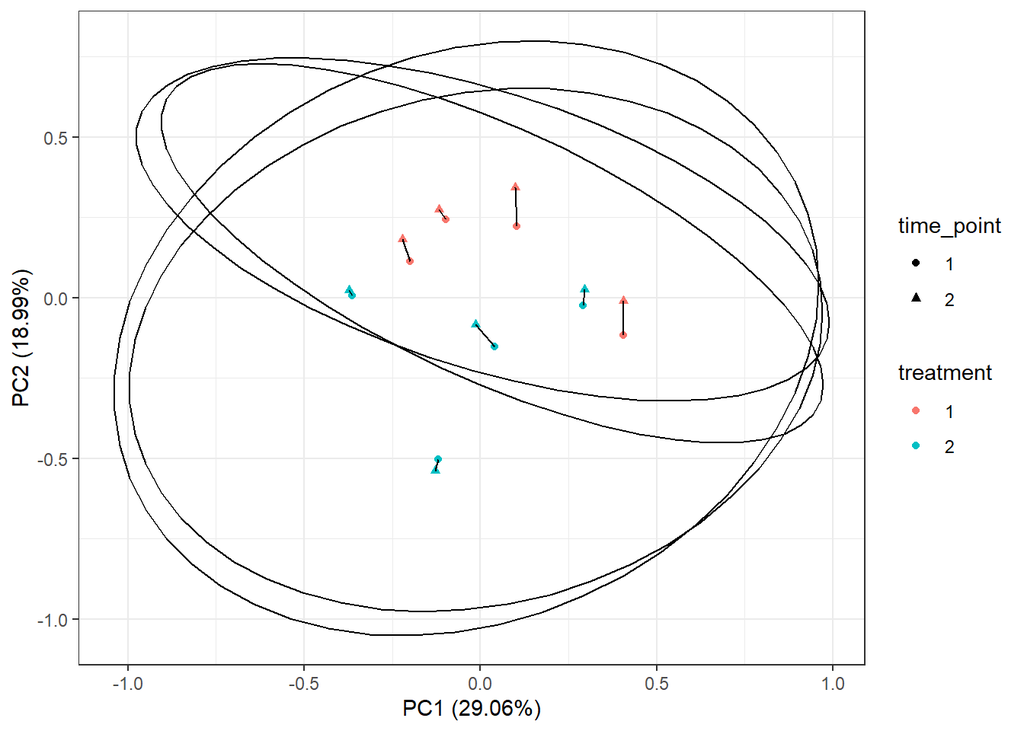

```r
pca_out <- prcomp(toy_data_merged)
autoplot(pca_out, data = toy_data_design, colour="treatment", shape="time_point") +
  theme_bw() +
  geom_line(aes(group=subject)) +
  stat_ellipse(aes(group=interaction(treatment, time_point)))
```

There is no obvious treatment effect in the regular pca

```r
mpca <- pca(X = toy_data_merged, multilevel = toy_data_design$subject, ncomp = 10)
```

```
## Splitting the variation for 1 level factor.
```

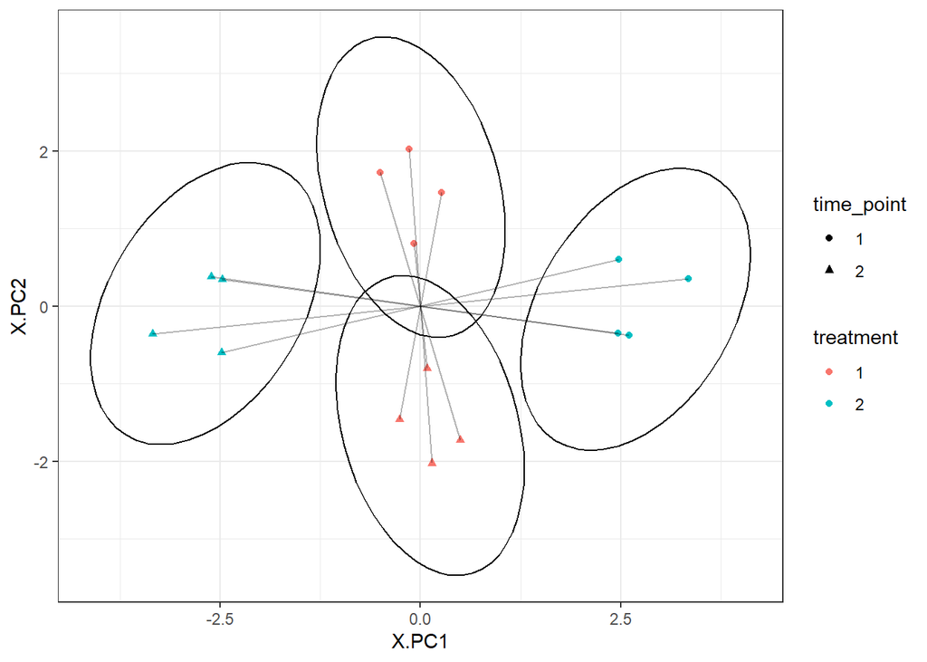

```r
df <- cbind(mpca$variates, toy_data_design)

ggplot(df, aes(x=X.PC1, y=X.PC2)) +
  theme_bw() +
  geom_point(aes(color=treatment, shape=time_point)) +
  geom_line(aes(group=subject), alpha=0.3) +
  stat_ellipse(aes(group=interaction(treatment, time_point)))
```

Now we can see an obvious effect of time and treatment.

# Summary

This is of course an exaggerated example, but it shows how inter-individual variance can obscure treatment effects. Especially in microbiome data, inter-individual variance is usally largerer than treatment effects.